# Lab Assignment 7

Summer Heschong

2025-02-26

#Setup

```r
library(here)
library(tidyverse)
library(dunn.test)
library(gt)
library(paletteer)

#load data set
vert_data <- read.csv(here('Data/Raw/and_vertebrates.csv'))

#filter data set for cutthroat trout
trout_data <- vert_data %>%
  filter(species == 'Cutthroat trout')
```

#(1) Mann-Whitney U and Wilcoxon Signed-Rank Tests ##a. Examine normality of data and run a Mann-Whitney U test

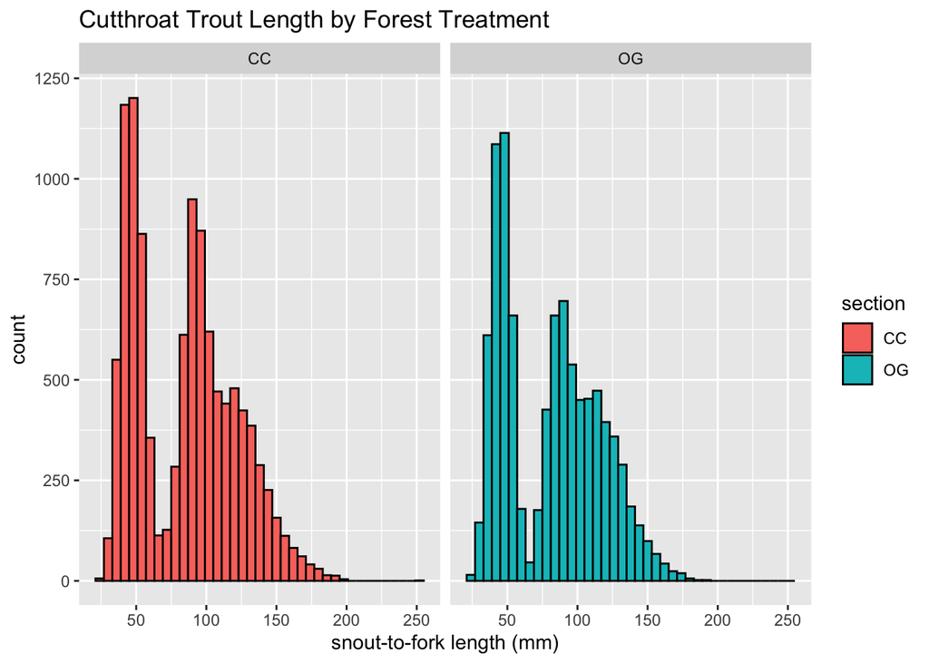

```r
#visualize data
fig1 <- ggplot(trout_data, aes(x = length_1_mm, fill = section)) +
  geom_histogram(bins = 30, binwidth = 6, color = 'black') +
  facet_wrap(~section) +
  labs(title = 'Cutthroat Trout Length by Forest Treatment',
       x = 'snout-to-fork length (mm)')
fig1
```

```r
#run Mann-Whitney U test

#First separate fish lengths by forest treatment type
CCtrout_data <- trout_data %>%
  filter(section == 'CC')
OGtrout_data <- trout_data %>%
  filter(section == 'OG')

#Are ranks of fish lengths significantly different between forest treatment types?
wilcox.test(CCtrout_data$length_1_mm,
            OGtrout_data$length_1_mm,
            paired = FALSE)
```

```
##
##  Wilcoxon rank sum test with continuity correction
##
## data:  CCtrout_data$length_1_mm and OGtrout_data$length_1_mm
## W = 55178843, p-value = 7.697e-16
## alternative hypothesis: true location shift is not equal to 0
```

Answer: There was a significant difference in ranks between cutthroat trout snout-to-fork length in clear-cut forest (median = 88mm, IQR = 50-111mm) and in old growth forests (median = 84mm, IQR = 48-108mm) as determined by a Mann-Whitney U Test (W = 55,178,843, p = 7.7e-16).

##b. Visualize data to assess normality and run a Wilcoxon Signed-Rank test

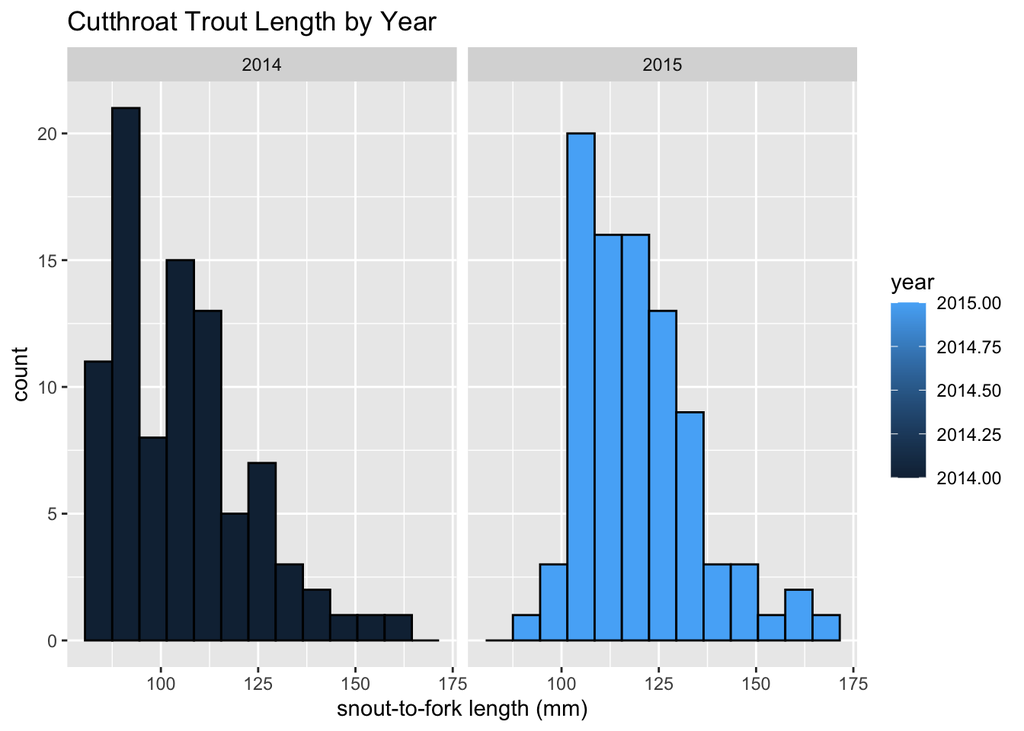

```r
#load in new dataset
recapture_data <- read.csv(here('Data/Raw/trout_recapture_v2.csv'))

#visualize data
fig2 <- ggplot(recapture_data, aes(x = length_1_mm, fill = year)) +
  geom_histogram(bins = 11, binwidth = 7, color = 'black') +
  facet_wrap(~year) +
  labs(title = 'Cutthroat Trout Length by Year',
       x = 'snout-to-fork length (mm)')
fig2
```

```r
#run Wilcoxon Signed-Rank test
#first separate data by year
trout2014 <- recapture_data %>%
  filter(year == '2014')
trout2015 <- recapture_data %>%
  filter(year == '2015')

#Are ranks of fish lengths significantly different between years?
wilcox.test(trout2014$length_1_mm,
            trout2015$length_1_mm,
            paired = TRUE)
```

```
##
##  Wilcoxon signed rank test with continuity correction
##
## data:  trout2014$length_1_mm and trout2015$length_1_mm
## V = 625.5, p-value = 4.973e-08
## alternative hypothesis: true location shift is not equal to 0
```

Answer: There was a significant difference in ranks between cutthroat trout snout-to-fork length in 2014 (median = 104mm, IQR = 91-114mm) and in 2015 (median = 118mm, IQR = 108-127mm) as determined by a Wilcoxon Signed Rank Test (V = 625.5, p = 4.97e-08).

#(2) Kruskal Wallis and post-hoc Dunn’s Tests ##a. Visualize data and run a Kruskal Wallis test

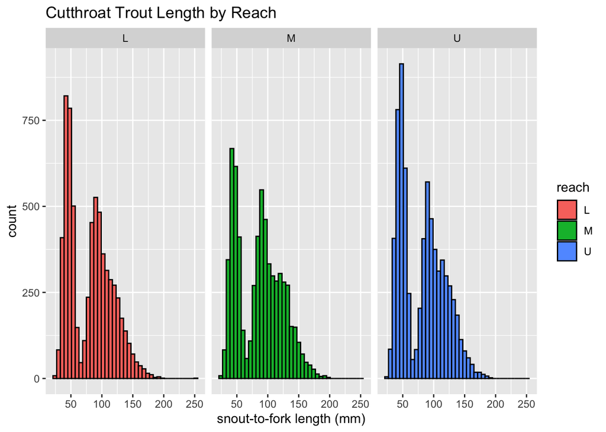

```r
#Visualize Data
fig3 <- ggplot(trout_data, aes(x = length_1_mm, fill = reach)) +
  geom_histogram(bins = 37, binwidth = 6, color = 'black') +
  facet_wrap(~reach) +
  labs(title = 'Cutthroat Trout Length by Reach',
       x = 'snout-to-fork length (mm)')
fig3
```

```r
#Run a Kruskal Wallis Test to see if ranks of fish lengths are significantly different among stream reaches
kruskal.test(length_1_mm ~ reach, data = trout_data)
```

```
##
##  Kruskal-Wallis rank sum test
##
## data:  length_1_mm by reach
## Kruskal-Wallis chi-squared = 77.394, df = 2, p-value < 2.2e-16
```

```r
#Ranks are significantly different -> run a Dunn's test
dunn.test(trout_data$length_1_mm, trout_data$reach)
```

```
##   Kruskal-Wallis rank sum test
##
## data: x and group
## Kruskal-Wallis chi-squared = 77.3942, df = 2, p-value = 0
##
##
##                            Comparison of x by group
##                                 (No adjustment)
## Col Mean-|
## Row Mean |          L          M
## ---------+----------------------
##        M |  -8.305134
##          |    0.0000*
##        U |  -1.688937   6.770059
##          |     0.0456    0.0000*
##
## alpha = 0.05
## Reject Ho if p <= alpha/2
```

```r
#calculate central tendencies of reach sections for report
#filter reach by section
reach_L <- trout_data %>%
  filter(reach == 'L')
reach_M <- trout_data %>%
  filter(reach == 'M')
reach_U <- trout_data %>%
  filter(reach == 'U')

#calculate medians
median(reach_L$length_1_mm, na.rm = TRUE)
```

```
## [1] 85
```

```r
median(reach_M$length_1_mm, na.rm = TRUE)
```

```
## [1] 89
```

```r
median(reach_U$length_1_mm, na.rm = TRUE)
```

```
## [1] 85
```

```r
#calculate IQR
quantile(reach_L$length_1_mm, 0.25, na.rm = TRUE)
```

```
## 25%
##  48
```

```r
quantile(reach_L$length_1_mm, 0.75, na.rm = TRUE)
```

```
## 75%
## 107
```

```r
quantile(reach_M$length_1_mm, 0.25, na.rm = TRUE)
```

```
## 25%
##  51
```

```r
quantile(reach_M$length_1_mm, 0.75, na.rm = TRUE)
```

```
## 75%
## 114
```

```r
quantile(reach_U$length_1_mm, 0.25, na.rm = TRUE)
```

```
## 25%
##  48
```

```r
quantile(reach_U$length_1_mm, 0.75, na.rm = TRUE)
```

```
## 75%
## 109
```

Answer: There was a significant difference in ranks between reach section L (median = 85mm, IQR = 48-107mm) and M (median = 89mm, IQR = 51-114mm) and between M (median = 89mm, IQR = 51-114mm) and U (median = 85mm, IQR = 48-109mm), but not between L (median = 85mm, IQR = 48-107mm) and U (median = 85mm, IQR = 48-109mm) as determined by a Kruskal Wallis test (Kruskal-Wallis chi-squared = 77.394, df = 2, p-value < 2.2e-16) and post-hoc Dunn’s test (Kruskal-Wallis chi-squared = 77.3942, df = 2, p-value = 0).

##b.Visualize results of Kruskal Wallis and Dunn’s Tests

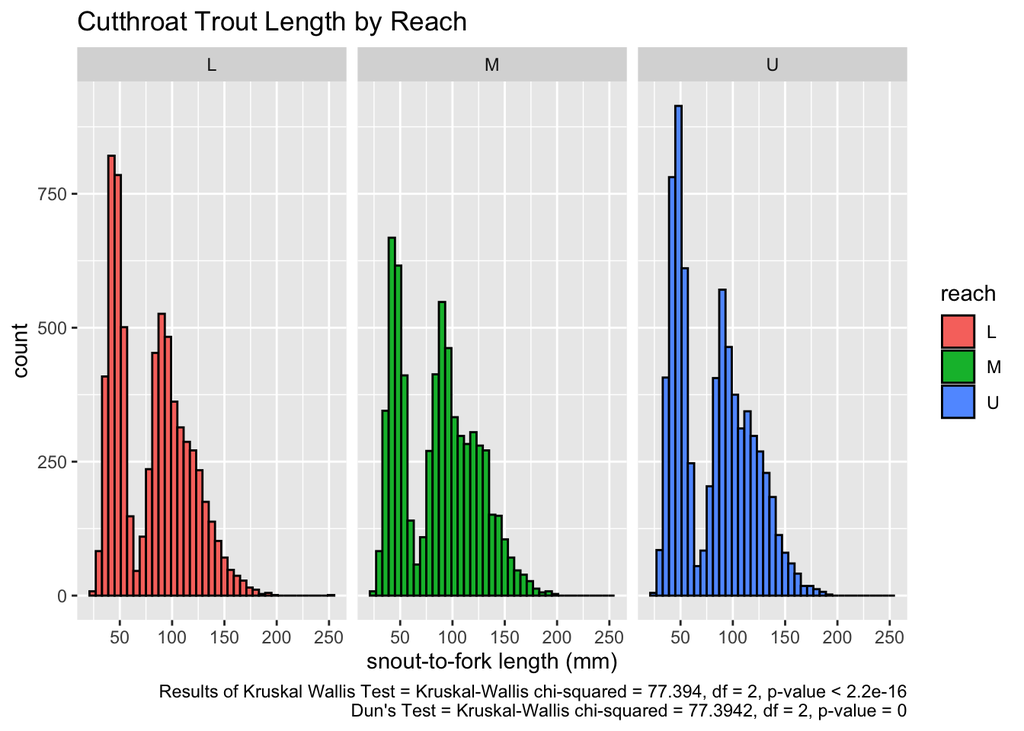

```r
fig4 <- ggplot(trout_data, aes(x = length_1_mm, fill = reach)) +
  geom_histogram(bins = 37, binwidth = 6, color = 'black') +
  facet_wrap(~reach) +
  labs(title = 'Cutthroat Trout Length by Reach',
       x = 'snout-to-fork length (mm)',
       caption = "Results of Kruskal Wallis Test = Kruskal-Wallis chi-squared = 77.394, df = 2, p-value < 2.2e-16
Dun's Test = Kruskal-Wallis chi-squared = 77.3942, df = 2, p-value = 0")
fig4
```

#(3) Contingency Tables and the Chi-Squared Test ##a. Create a Contingency Table

```r
#get data ready for contingency table
contingency_table <- trout_data %>%
  group_by(reach, unittype) %>%
  summarise(trout_count = n()) %>%
  pivot_wider(names_from = unittype, values_from = trout_count, values_fill = 0) %>%
  column_to_rownames(var = "reach")
#create table
fish_counts <- contingency_table %>%
  gt(rowname_col = 'Reach') %>%
  tab_header(title = 'Fish Counts by Reach and Habitat Type') %>%
  grand_summary_rows(columns = c(C, I, IP, P, R, S, SC),
    fns = list(Total = ~sum(., na.rm = TRUE)),
    use_seps = TRUE
    ) %>%
    data_color(columns = c(C, I, IP, P, R, S, SC),
    palette = c("#C0D8F0", "#5A7ECB"),
    alpha = 0.75)
fish_counts
```

Fish Counts by Reach and Habitat Type

|  | C | I | IP | P | R | S | SC | NA |
| --- | --- | --- | --- | --- | --- | --- | --- | --- |
|  | 3951 | 7 | 79 | 1218 | 33 | 2 | 1205 | 220 |
|  | 2984 | 0 | 6 | 2121 | 94 | 0 | 1106 | 210 |
|  | 4484 | 16 | 20 | 2131 | 293 | 7 | 66 | 180 |
| Total | 11419 | 23 | 105 | 5470 | 420 | 9 | 2377 | — |

##b. Run a Chi-Squared Test H0: There is no significant effect of reach on fish counts in different habitat types HA: There is a significant effect of reach on fish counts in different habitat types

```r
#run a Chi-Squared test
chi_test <- chisq.test(contingency_table)
chi_test
```

```
##
##  Pearson's Chi-squared test
##
## data:  contingency_table
## X-squared = 1925.5, df = 14, p-value < 2.2e-16
```

```r
#examine observed counts
chi_test$observed
```

```
##      C  I IP    P   R S   SC  NA
## L 3951  7 79 1218  33 2 1205 220
## M 2984  0  6 2121  94 0 1106 210
## U 4484 16 20 2131 293 7   66 180
```

Answer: There was found to be a significant effect of reach on fish counts in different habitat types as determined by a chi-squared test (x^2 = 1,925.5, p < 2.2e-16). For each reach L,M, and U habitat C had the highest fish count.